# batch-effects

## batch-effects

*Last modified 03:39 PM on Apr 03, 2015. This document, R session image, knitr cache, figures, and other associated datasets are located in `cruncher:/inside/grotto/blin/trna-markers/prad/batch-effects/`.*

```r
library(sva)
library(GenomicRanges)
library(DESeq2)
library(ggplot2)
library(BiocParallel)
register(MulticoreParam(8)) # turn this off depending on your machine!
attach('/inside/grotto/blin/trna-markers/feature-counts/feature-counts.RData')
attach('/inside/grotto/blin/trna-markers/process-reads/prad-metadata.RData')
```

TCGA data may contain batch effects that need to be removed. I normalize the data with [`DESeq2`](http://www.bioconductor.org/packages/release/bioc/html/DESeq2.html) and use the [`sva`](http://www.bioconductor.org/packages/release/bioc/html/sva.html) package to remove them.

### Normalize counts

Let's load the `.RData` file and normalize the counts using `DESeq2`. For this first step, we will also eliminate features that have 0 counts for over 95% of the samples. This means that for a tRF or miRNA to be considered in the analysis, the feature must have at least 20 reads and be expressed in at least 5% of samples. These filters are stricter than usual because reads can be mapped to multiple loci, so a sample with 10 mapped locations may really just be the same read mapped 10 times.

```r
feature_counts <- feature_counts[apply(feature_counts, 1, function(row) length(which(row > 0)) > length(colnames(feature_counts)) * 0.05), ] # no. of samples with reads mapping to this feature > no. samples * 0.05
feature_counts <- feature_counts[apply(feature_counts, 1, function(row) sum(row) > 20), ]
```

```r
colData <- data.frame(row.names = colnames(feature_counts), condition = prad_metadata$sample_type, type = "single-read") # feature count column names correspond to metadata rows
dds <- DESeqDataSetFromMatrix(countData = feature_counts, colData = colData, design = ~ condition)
dds <- estimateSizeFactors(dds)
```

We don't need the entire DESeq analysis pipeline. The only thing of interest is the scaling factors which we can now apply to our hg19 feature counts.

```r
normalized_counts <- t(t(feature_counts) / sizeFactors(dds)) # R applies vectors on columns (genes), we want R to apply them on rows (samples) for size factors
```

## Remove batch effects

```r
pheno_data <- data.frame(row.names = prad_metadata$barcode, sample_type = prad_metadata$sample_type)
mod <- model.matrix(~ 1, data = pheno_data)
batch <- as.factor(ifelse(!is.na(prad_metadata$batch), as.character(prad_metadata$batch), "Batch Unknown"))
batch_removed_counts <- ComBat(dat = normalized_counts, batch = batch, mod = mod)
```

```
## Found 19 batches
## Found 0  categorical covariate(s)
## Standardizing Data across genes
## Fitting L/S model and finding priors
## Finding parametric adjustments
## Adjusting the Data
```

## PCA

To look at the effectiveness of ComBat, I will project pre- and post-ComBat expression data onto its principle components.

```r
plotPCA <- function(counts) {
  pca <- prcomp(counts, scale = TRUE)
  pca_scores <- as.data.frame(pca$x)
  ggplot(pca_scores, aes(x = PC1, y = PC2)) + geom_point(shape = 1)
}
plotPCACancerType <- function(normalized_counts, adjusted_counts, metadata, cancer_code) {
    plotPCA(t(normalized_counts)[, metadata$sample_type == "TP"]) + ggtitle(paste(cancer_code, "TP Before"))
    plotPCA(t(adjusted_counts)[, metadata$sample_type == "TP"]) + ggtitle(paste(cancer_code, "TP After"))
    plotPCA(t(normalized_counts)[, metadata$sample_type == "NT"]) + ggtitle(paste(cancer_code, "NT Before"))
    plotPCA(t(adjusted_counts)[, metadata$sample_type == "NT"]) + ggtitle(paste(cancer_code, "NT After"))
}
```

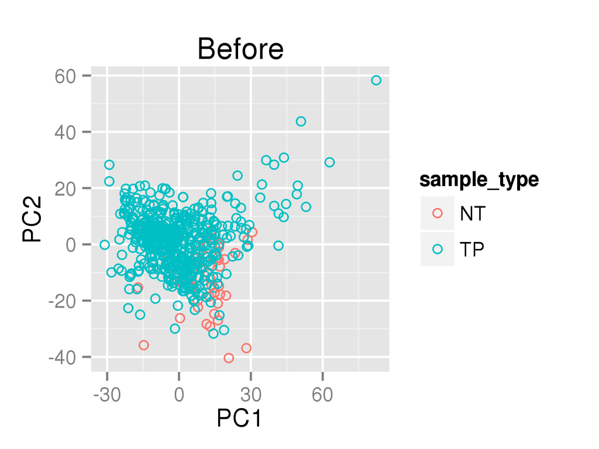

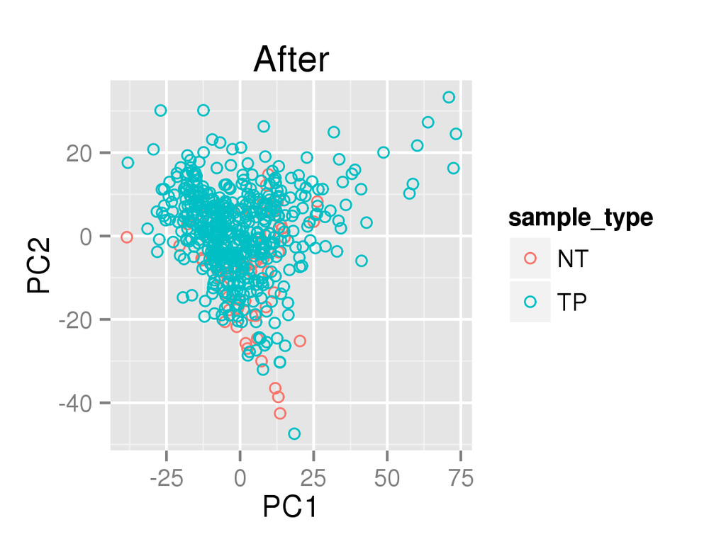

```r
# separate by tissue type - otherwise will just cluster by cancer incidence
pca <- as.data.frame(prcomp(t(normalized_counts), scale = TRUE)$x)
pca$sample_type <- prad_metadata$sample_type
ggplot(pca, aes(x = PC1, y = PC2, color = sample_type)) + geom_point(shape = 1) + ggtitle("Before")
pca <- as.data.frame(prcomp(t(batch_removed_counts), scale = TRUE)$x)
pca$sample_type <- prad_metadata$sample_type
ggplot(pca, aes(x = PC1, y = PC2, color = sample_type)) + geom_point(shape = 1) + ggtitle("After")
```

It doesn't look like ComBaT is achieving a lot. I will just use the normalized counts instead.

## Differential expression

```r
tRF_normalized_counts <- normalized_counts[!features$class[match(rownames(normalized_counts), features$tx_name)] %in% c("miRNA", "5half", "3half"), ]
colData <- data.frame(row.names = colnames(normalized_counts), condition = prad_metadata$sample_type, type = "single-read")  # feature count column names correspond to metadata rows
dds <- DESeqDataSetFromMatrix(countData = normalized_counts, colData = colData, design = ~ condition)
```

```
## Error in DESeqDataSet(se, design = design, ignoreRank): some values in assay are not integers
```

```r
dds <- DESeq(dds)
deseq_results <- results(dds)[order(results(dds)$padj), ]
```

```r
save(file = "counts.RData", batch_removed_counts, normalized_counts)
save(file = "deseq-results.RData", deseq_results)
save.image("batch-effects-image.RData")
```